# assignment

2023-05-03

# Assignment

## Download ATAC-seq peak counts in the hippocampus upon stress (subset of the original data, already in SummarizedExperiment format) :

### https://ethz-ins.org/content/mouse_mm38_hippocampus.peakCounts.SE.rds

### Using this object, perform a chromVAR motif analysis, and run 2 differential motif accessibility analyses, respectively:

#### comparing stressed (denoted ‘FSS’ – forced swim stress) and control animals

#### comparing male and female animals

####For each analysis, report the top most significant motifs, plot a heatmap of the normalized accessibility scores across the samples for those motifs, and write a short paragraph interpreting the results.

##### Save your assignment in a R markdown named assignment.Rmd, render it, and push the html file to this folder in your github repository

```r
# Load necessary libraries
suppressPackageStartupMessages({
  library(epiwraps) # data handling and analysis
  library(motifmatchr) # motif analysis
  library(MotifDb) # motif database
  library(universalmotif) # motif analysis
  library(sechm) # heatmap visualization
  library(BiocParallel) # parallelization
  library(ggplot2) # data visualization
  library(chromVAR) # motif accessibility estimation
  library(SummarizedExperiment) # data structure
  library(limma) # statistical analysis
})
```

```
## See system.file("LICENSE", package="MotifDb") for use restrictions.
```

```r
# Set up multithreading for faster processing
# register(MulticoreParam(4)) for unix users
# for windows users, rather one of the following:
# register(SerialParam())
# register(SnowParam(2))
```

## Download the data

```r
options(timeout=6000)# set timeout in case of slow download
# Download the data
download.file("https://ethz-ins.org/content/mouse_mm38_hippocampus.peakCounts.SE.rds", "mouse_mm38_hippocampus.peakCounts.SE.rds")
```

```r
# Load the MotifDb package and query it for motifs for the Mus musculus species
library(MotifDb)
motif <- MotifDb::query(MotifDb, "Mmusculus")
motif
```

```
## MotifDb object of length 1571
## | Created from downloaded public sources, last update: 2022-Mar-04
## | 1571 position frequency matrices from 9 sources:
## |         cisbp_1.02:  132
## |        HOCOMOCOv10:  426
## |        JASPAR_2014:   66
## |        JASPAR_CORE:   47
## |         jaspar2016:  165
## |         jaspar2018:  176
## |         jaspar2022:  144
## |          jolma2013:  133
## |           UniPROBE:  282
## | 9 organism/s
## |          Mmusculus: 1554
## | Mmusculus;Rnorvegicus;Hsapiens:    6
## | Mmusculus;Hsapiens:    3
## | Mmusculus;Rnorvegicus:    2
## | Mmusculus;Rnorvegicus;Xlaevis;Stropicalis;Ggallus;Hsapiens;Btaurus;Ocuniculus:    2
## | Hsapiens;Ocuniculus;Mmusculus;Rrattus:    1
## |              other:    3
## Mmusculus-cisbp_1.02-M0082_1.02
## Mmusculus-cisbp_1.02-M0083_1.02
## Mmusculus-cisbp_1.02-M0084_1.02
## Mmusculus-cisbp_1.02-M0085_1.02
## Mmusculus-cisbp_1.02-M0104_1.02
## ...
## Mmusculus-UniPROBE-Zfp740.UP00022
## Mmusculus-UniPROBE-Zic1.UP00102
## Mmusculus-UniPROBE-Zic2.UP00057
## Mmusculus-UniPROBE-Zic3.UP00006
## Mmusculus-UniPROBE-Zscan4.UP00026
```

```r
# Load the AnnotationHub and Biostrings packages
library(AnnotationHub)
library(Biostrings)
# Create a local AnnotationHub and get the genome sequence for Mus musculus
ah <- AnnotationHub(localHub=TRUE)
```

```
## Using 'localHub=TRUE'
##   If offline, please also see BiocManager vignette section on offline use
```

```
## snapshotDate(): 2023-04-06
```

```r
genome <- ah[["AH68356"]]
```

```
## loading from cache
```

```
## require("rtracklayer")
```

```r
genome_seq <- Biostrings::getSeq(genome)
tail(genome_seq)
```

```
## DNAStringSet object of length 6:
##     width seq                                               names
## [1] 23158 CATAAAACATTTTGTGCAATCTC...ATCAAAAGATGGCCTAGTCGGCC GL456382.1
## [2] 22974 CTGCTGCTTGCTATGGCTGGTAA...AGCAACCCTGACCTGCTCCCGTG GL456359.1
## [3] 21240 TCCTTGGGGGGCATACGCCCAGA...GAAAATGAGACACAAACACTGTA GL456396.1
## [4] 20208 GAAGGAAGGAAGGAAGGAAGGAA...ACTCTGTTGCAGGCTGCCTTCCA GL456368.1
## [5] 14945 GTGTGTGTGTGTGTGTGTGTGTG...GCCCGAGAGGTTTCTGCCTCAGG JH584292.1
## [6]  1976 GGCTGAGCGGTGACATCATGGGC...ACCGCACTGGGCAGAAGCCCGTG JH584295.1
```

## Get the database of motifs

```r
## Get the database of motifs
# Query the MotifDb package for the JASPAR_CORE motifs and the Mus musculus species
motifs <- MotifDb::query(MotifDb, c("JASPAR_CORE", "Mmusculus"))
length(motifs)
```

```
## [1] 47
```

```r
# Query the MotifDb package for the HOCOMOCOv11-core motifs and the Homo sapiens species
motifs <- MotifDb::query(MotifDb, c("HOCOMOCOv11-core", "Hsapiens"))
length(motifs)
```

```
## [1] 400
```

```r
# Use TFBSTools and universalmotif packages to convert the motifs to PWM format and set their names to the gene symbol
motifs <- do.call(TFBSTools::PWMatrixList, setNames(
           universalmotif::convert_motifs(motifs, class="TFBSTools-PWMatrix"),
           mcols(motifs)$geneSymbol))
```

```r
# Load the data object
file_musmusculus_hippocampus <- "mouse_mm38_hippocampus.peakCounts.SE.rds"
sedata <- readRDS(file_musmusculus_hippocampus)
sedata
```

```
## class: RangedSummarizedExperiment
## dim: 20660 12
## metadata(0):
## assays(1): counts
## rownames: NULL
## rowData names(0):
## colnames(12): Control_female_GSM6041841.bam
##   Control_female_GSM6041842.bam ... FSS_male_GSM6041857.bam
##   FSS_male_GSM6041858.bam
## colData names(1): depth
```

```r
colnames(sedata)
```

```
##  [1] "Control_female_GSM6041841.bam" "Control_female_GSM6041842.bam"
##  [3] "Control_female_GSM6041843.bam" "Control_male_GSM6041844.bam"
##  [5] "Control_male_GSM6041845.bam"   "Control_male_GSM6041846.bam"
##  [7] "FSS_female_GSM6041853.bam"     "FSS_female_GSM6041854.bam"
##  [9] "FSS_female_GSM6041855.bam"     "FSS_male_GSM6041856.bam"
## [11] "FSS_male_GSM6041857.bam"       "FSS_male_GSM6041858.bam"
```

```r
sedata$condition <- c("CTRL","CTRL","CTRL", "CTRL","CTRL","CTRL", "FSS", "FSS", "FSS", "FSS", "FSS", "FSS")
sedata$condition  # add a "condition" column to the main object with the same values as in the previous step
```

```
##  [1] "CTRL" "CTRL" "CTRL" "CTRL" "CTRL" "CTRL" "FSS"  "FSS"  "FSS"  "FSS"
## [11] "FSS"  "FSS"
```

```r
colData(sedata)# add a "condition" column to colData with the condition of each sample
```

```
## DataFrame with 12 rows and 2 columns
##                                   depth   condition
##                               <numeric> <character>
## Control_female_GSM6041841.bam  73170149        CTRL
## Control_female_GSM6041842.bam  93995034        CTRL
## Control_female_GSM6041843.bam  40167775        CTRL
## Control_male_GSM6041844.bam    70491005        CTRL
## Control_male_GSM6041845.bam    84985977        CTRL
## ...                                 ...         ...
## FSS_female_GSM6041854.bam      73674456         FSS
## FSS_female_GSM6041855.bam      49285912         FSS
## FSS_male_GSM6041856.bam        82385764         FSS
## FSS_male_GSM6041857.bam        68623011         FSS
## FSS_male_GSM6041858.bam        81801232         FSS
```

```r
# correct for GC bias
sedata <- chromVAR::addGCBias(sedata, genome=genome_seq)
# find the enriched motifs
moi <- motifmatchr::matchMotifs(motifs, subject=sedata, genome=genome_seq)
moi
```

```
## class: RangedSummarizedExperiment
## dim: 20660 400
## metadata(0):
## assays(1): motifMatches
## rownames: NULL
## rowData names(1): bias
## colnames(400): AHR AIRE ... ZNF8 ZSC22
## colData names(1): name
```

```r
# compute deviation scores
dev <- chromVAR::computeDeviations(object = sedata, annotations=moi,
                                   background_peaks=getBackgroundPeaks(sedata, niterations=1000))
dev
```

```
## class: chromVARDeviations
## dim: 400 12
## metadata(0):
## assays(2): deviations z
## rownames(400): AHR AIRE ... ZNF8 ZSC22
## rowData names(3): name fractionMatches fractionBackgroundOverlap
## colnames(12): Control_female_GSM6041841.bam
##   Control_female_GSM6041842.bam ... FSS_male_GSM6041857.bam
##   FSS_male_GSM6041858.bam
## colData names(2): depth condition
```

```r
# check the column data of the deviation object
colData(dev)
```

```
## DataFrame with 12 rows and 2 columns
##                                   depth   condition
##                               <numeric> <character>
## Control_female_GSM6041841.bam  73170149        CTRL
## Control_female_GSM6041842.bam  93995034        CTRL
## Control_female_GSM6041843.bam  40167775        CTRL
## Control_male_GSM6041844.bam    70491005        CTRL
## Control_male_GSM6041845.bam    84985977        CTRL
## ...                                 ...         ...
## FSS_female_GSM6041854.bam      73674456         FSS
## FSS_female_GSM6041855.bam      49285912         FSS
## FSS_male_GSM6041856.bam        82385764         FSS
## FSS_male_GSM6041857.bam        68623011         FSS
## FSS_male_GSM6041858.bam        81801232         FSS
```

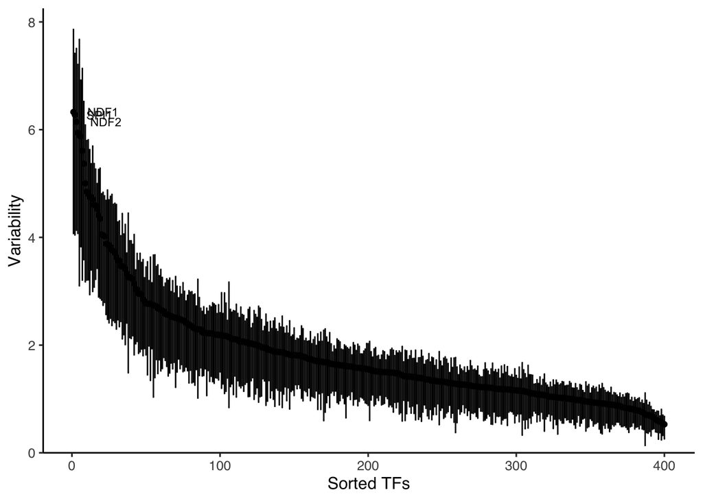

```r
# compute variability for the deviation scores
variability <- computeVariability(dev)
plotVariability(variability)
```

```r
# scale deviation scores
head(assays(dev)$z)
```

```
##      Control_female_GSM6041841.bam Control_female_GSM6041842.bam
## AHR                    -0.53149699                     0.1754308
## AIRE                   -0.02570113                    -0.4368456
## ALX1                    0.61661435                     0.2894886
## ANDR                    1.35790895                    -2.0147415
## AP2A                    2.49713023                    -0.4013998
## AP2B                    2.00987318                    -0.4907252
##      Control_female_GSM6041843.bam Control_male_GSM6041844.bam
## AHR                      0.4117138                  -0.3382215
## AIRE                    -2.3360150                   1.9272498
## ALX1                    -0.2510673                  -0.3081482
## ANDR                    -0.9075649                   2.2031173
## AP2A                    -2.0001969                   3.0826707
## AP2B                    -1.1402649                   1.7447550
##      Control_male_GSM6041845.bam Control_male_GSM6041846.bam
## AHR                   0.65519845                  -0.7077341
## AIRE                 -0.03510788                  -0.2383597
## ALX1                  0.42296728                  -1.2228101
## ANDR                 -1.23183488                   0.5218369
## AP2A                  0.86257832                   2.4461702
## AP2B                 -1.07171272                   0.5808102
##      FSS_female_GSM6041853.bam FSS_female_GSM6041854.bam
## AHR                  0.8281119                -0.2839142
## AIRE                 0.9208097                 1.3808191
## ALX1                -0.6593411                 0.7503616
## ANDR                 2.6034387                -1.0504950
## AP2A                 1.6553120                -3.0610541
## AP2B                 0.9126761                -0.3131886
##      FSS_female_GSM6041855.bam FSS_male_GSM6041856.bam FSS_male_GSM6041857.bam
## AHR                 -1.2104955              -1.0078248               0.5779293
## AIRE                 0.6985942               1.6432728               1.4915758
## ALX1                 0.1707452               0.7058624              -0.3589038
## ANDR                 2.1772949               0.2669748               3.2691625
## AP2A                 2.0150357               1.6994584               0.9287359
## AP2B                 0.2285058               1.4415879               0.9531560
##      FSS_male_GSM6041858.bam
## AHR               0.02030532
## AIRE              0.31361835
## ALX1             -0.32798547
## ANDR             -1.39068268
## AP2A              0.12416705
## AP2B             -0.55842904
```

```r
assays(dev)$norm <- scale(assays(dev)$z)
dev
```

```
## class: chromVARDeviations
## dim: 400 12
## metadata(0):
## assays(3): deviations z norm
## rownames(400): AHR AIRE ... ZNF8 ZSC22
## rowData names(3): name fractionMatches fractionBackgroundOverlap
## colnames(12): Control_female_GSM6041841.bam
##   Control_female_GSM6041842.bam ... FSS_male_GSM6041857.bam
##   FSS_male_GSM6041858.bam
## colData names(2): depth condition
```

# Differential analysis

#### Using this object, perform a chromVAR motif analysis, and run 2 differential motif accessibility analyses, respectively:

#### comparing stressed (denoted ‘FSS’ – forced swim stress) and control animals

#### comparing male and female animals

#### For each analysis, report the top most significant motifs, plot a heatmap of the normalized accessibility scores across the samples for those motifs, and write a short paragraph interpreting the results.

```r
# comparing stressed (denoted ‘FSS’ – forced swim stress) and control animals
dev$condition
```

```
##  [1] "CTRL" "CTRL" "CTRL" "CTRL" "CTRL" "CTRL" "FSS"  "FSS"  "FSS"  "FSS"
## [11] "FSS"  "FSS"
```

```r
# if needed, we can specify the baseline condition, by default it's the first in alphabetical order
dev$condition <- factor(dev$condition)
# set the baseline condition to "CTRL"
dev$condition <- relevel(dev$condition, "CTRL")
# create a model matrix for the comparison
mm <- model.matrix(~dev$condition)
# equivalent:
mm <- model.matrix(~condition, data=as.data.frame(colData(dev)))
mm
```

```
##                               (Intercept) conditionFSS
## Control_female_GSM6041841.bam           1            0
## Control_female_GSM6041842.bam           1            0
## Control_female_GSM6041843.bam           1            0
## Control_male_GSM6041844.bam             1            0
## Control_male_GSM6041845.bam             1            0
## Control_male_GSM6041846.bam             1            0
## FSS_female_GSM6041853.bam               1            1
## FSS_female_GSM6041854.bam               1            1
## FSS_female_GSM6041855.bam               1            1
## FSS_male_GSM6041856.bam                 1            1
## FSS_male_GSM6041857.bam                 1            1
## FSS_male_GSM6041858.bam                 1            1
## attr(,"assign")
## [1] 0 1
## attr(,"contrasts")
## attr(,"contrasts")$condition
## [1] "contr.treatment"
```

```r
# fit a linear model and perform empirical Bayes moderated t-tests
fit <- eBayes(lmFit(assays(dev)$norm, mm))
fit
```

[output not shown]

[output cut: 82 more lines]

```
##      (Intercept) conditionFSS
## AHR    -4.642859    -6.113587
## AIRE   -4.607616    -4.622949
## ALX1   -4.637513    -6.157567
## ANDR   -4.641908    -5.801363
## AP2A   -4.589815    -6.095310
## 395 more rows ...
##
## $F
## [1] 0.22562043 1.86677870 0.08723979 0.50692528 0.73743592
## 395 more elements ...
##
## $F.p.value
## [1] 0.8008307 0.1906811 0.9169452 0.6128551 0.4958109
## 395 more elements ...
```

```r
# order the F.p.values to find the TFs with significant differential binding between conditions
order(fit$F.p.value)
```

```
##   [1] 106 251 172  27 306 170 270 160 173 313 178 180 253 187  95   2 370 217
##  [19]  94  87 222 179  16 188 314  93  90  35 324 234 171 395 210 274 279  65
##  [37]  34 280 196 215 240 264  86  10 312 223 237  97 352  96  98 169 377 208
##  [55] 294  49 332 126 227 242 360  23 386 159 236 142  85 303 246 369 376  42
##  [73]  69 147 252  68 198 182 232 394 315  84 103 328  41  20 311 378 302 320
##  [91] 397 139 228 209   5 184  19 206 213  43 304 216  88 263 277 354  11 155
## [109] 122 135 273 132 136 389 351 197 143  45 120 318 105 257  62 107 372 298
## [127]  26 323 275 181 299 175 393  92  39 108 337 373 363 356 398 109 127 235
## [145] 134   7  51 286  91 183 212   4 391 349  22 346 271 225 131 247 357 152
## [163] 148 104 199 284 111 166 113   8  99  44  31 158 291  38 327 256  75 309
## [181]  37 250 272 310 238  66  63  74 301 300 114 140  67  17 249 380 224  14
## [199]  77  52  32 115 255   9  21 368 156 305 220 157 219 117  79 177 174 230
## [217] 193 128  73 387  54  64  89 226  82  12  60 129 400 163 307 375 333  55
## [235] 192 118  70 316  71 269 211  53 146 342 338 189 137  57 353 339 292  80
## [253] 382   1  81 345 138 390 221 278 102 191  83 336 261 141 254  56  33 340
## [271]  28 268 239 366 145 343 123 285 317 350   6 130 289 162  24  46 144 176
## [289] 243 276 347 293 218  59 295 283 326 341 110 297 121  36 125 100 207 233
## [307]  48 194 201 335 229  50 322 358 359 190 385 168 101 186 334 321 282 149
## [325] 371  58 330  72 167 267 362   3 296 150  25 388 195 319  61 116 329  78
## [343] 133 259 392 355 153  76 331 308 260 361 287  30 367 383 204 379 185 281
## [361] 245 384  40 124 244 202  29 365 241  13 399 112 265 396 164 119 381 154
## [379] 161 364 348 203 266 151  47  18 290 374 344 214 262  15 205 165 258 200
## [397] 231 288 325 248
```

```r
fit$F.p.value[106]
```

```
## [1] 0.0002155965
```

```r
fit$F.p.value[251]
```

```
## [1] 0.0002862613
```

```r
fit$F.p.value[172]
```

```
## [1] 0.07055378
```

```r
# create a data frame with the top results and add the TF names
res <- as.data.frame(topTable(fit, number = Inf))
```

```
## Removing intercept from test coefficients
```

```r
head(res)
```

```
##            logFC     AveExpr         t      P.Value adj.P.Val         B
## GCR    4.3953250  0.21497987  5.670170 5.502740e-05 0.0153440  2.112238
## PRGR   3.6363267  0.24508572  5.484892 7.672002e-05 0.0153440  1.809368
## MEF2C -1.1752931 -0.14612902 -2.460813 2.727289e-02 0.9986954 -3.606652
## CDX1   0.8664029  0.03694409  2.201603 4.473135e-02 0.9986954 -4.046663
## MEF2A -0.9359173 -0.07173816 -2.135984 5.058243e-02 0.9986954 -4.154592
## SUH    0.8418654  0.12337291  2.078837 5.624858e-02 0.9986954 -4.247289
```

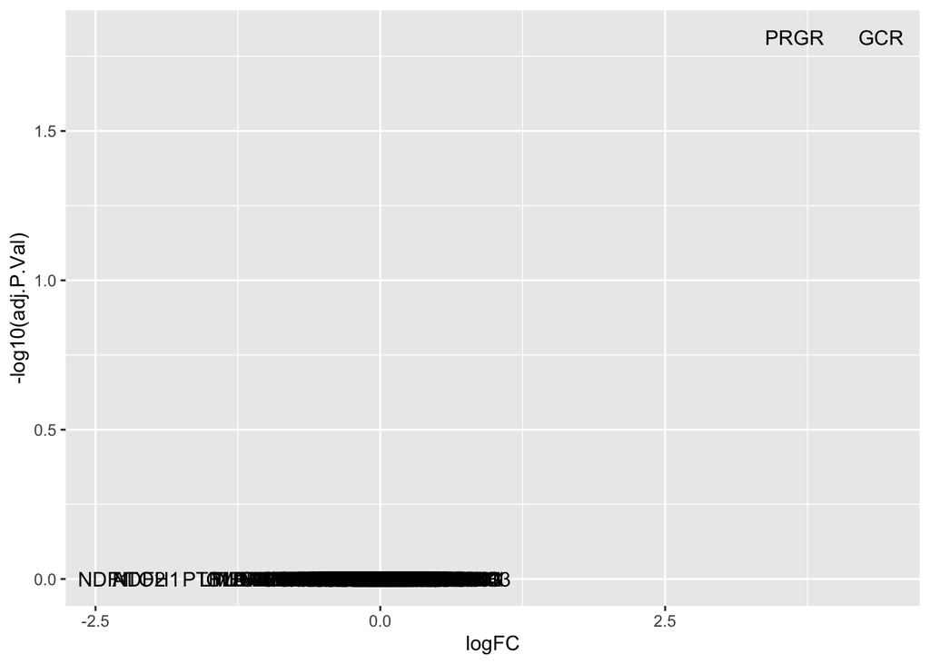

```r
res$TF <- row.names(res)
# plot the results with a heatmap
ggplot(res, aes(logFC, -log10(adj.P.Val), label=TF)) + geom_text()
```

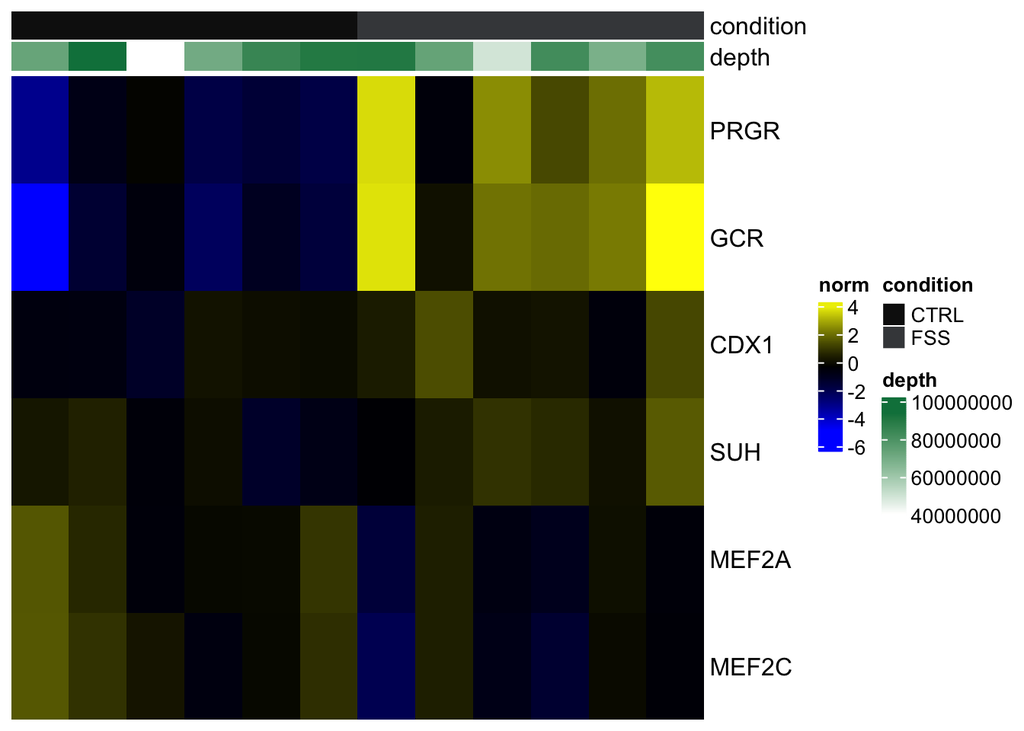

```r
sechm(dev, features = head(row.names(res)), assayName="norm", top_annotation = c("condition", "depth"))
```

the p-value indicates the likelihood that a result occurred by chance alone, while adjusted p-value (FDR->false discovery rate) controls the number of false positives among all significant results when multiple tests are performed simultaneously.

In the dataframe visible at the top you can see that the smallest p-values are for TF’s like GCR and PRGR

By looking at the heatmap, one can compare the relative accessibility and read count of peaks across the two conditions (CTRL and FSS).

From just looking at the heatmap one can see that the accessibility of the motifs for GCR and PRGR are higher in the stressed (FSS) condition compared to the control (CTRL) condition. This is indicated by the yellow color in the FSS state, which corresponds to higher motif accessibility values, and the blue/black color in the CTRL state, which corresponds to lower motif accessibility values.

```r
# add gender information to the deviation object
dev$gender <- c("FEMALE","FEMALE","FEMALE", "MALE","MALE","MALE", "FEMALE", "FEMALE", "FEMALE", "MALE", "MALE", "MALE")
dev$gender <- factor(dev$gender)
dev$gender <- relevel(dev$gender, c("FEMALE"))
dev$gender
```

```
##  [1] FEMALE FEMALE FEMALE MALE   MALE   MALE   FEMALE FEMALE FEMALE MALE
## [11] MALE   MALE
## Levels: FEMALE MALE
```

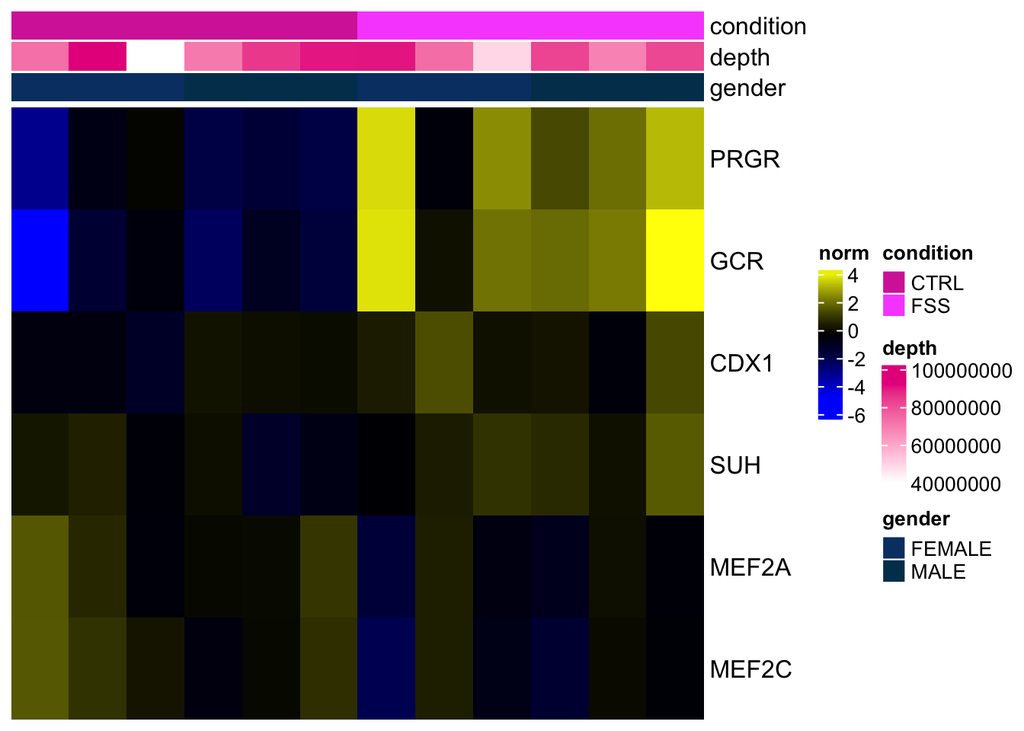

```r
# plot the heatmap with gender information
sechm(dev, features = head(row.names(res)), assayName="norm", top_annotation = c("condition", "depth", "gender"))
```

Adding another layer just shows us that female and male animals have a slightly different accessibility score when comparing the CTRL and FSS conditions. But there is a clear tendency showing that the motifs for GCR and PRGR are higher in the stressed (FSS) condition compared to the control (CTRL) condition.

# New model but for gender differences

```r
# create another model matrix for the comparison
mm2 <- model.matrix(~dev$gender)
mm2
```

```
##    (Intercept) dev$genderMALE
## 1            1              0
## 2            1              0
## 3            1              0
## 4            1              1
## 5            1              1
## 6            1              1
## 7            1              0
## 8            1              0
## 9            1              0
## 10           1              1
## 11           1              1
## 12           1              1
## attr(,"assign")
## [1] 0 1
## attr(,"contrasts")
## attr(,"contrasts")$`dev$gender`
## [1] "contr.treatment"
```

```r
# fit a linear model and perform empirical Bayes moderated t-tests
fit2 <- eBayes(lmFit(assays(dev)$norm, mm2))
fit2
```

[output not shown]

[output cut: 82 more lines]

```
##      (Intercept) dev$genderMALE
## AHR    -6.252041      -6.535199
## AIRE   -6.219260      -6.291941
## ALX1   -6.179974      -6.262071
## ANDR   -6.113874      -6.702673
## AP2A   -6.250189      -5.856858
## 395 more rows ...
##
## $F
## [1] 0.3707648 0.5821915 0.5428173 0.1605140 1.6388139
## 395 more elements ...
##
## $F.p.value
## [1] 0.6966194 0.5713191 0.5925668 0.8532118 0.2284972
## 395 more elements ...
```

```r
order(fit2$F.p.value)
```

```
##   [1] 345 329 335 374 325 400 334  55  50  47 307  54 392 327 319 322 151 292
##  [19] 154 293 371 138 265 259 337  56  21 393  13 196 267 262  53 289 362 140
##  [37] 310 290 175 330  59 163 197 333 210 218 382 266 321 224  60  43 141 300
##  [55] 132 149 176 379 167 338 324  64 135 346 299  75 291 242  57 136 331 361
##  [73] 257  58 303   7   8 253 128 364 100 398 212 126 301 130 311 377 198 204
##  [91] 211 320  61  11 137  25  88 153  70  10 368 315 261 328  85 260  42   5
## [109] 150 208 217 305 354 249 105  35  74 219  24 298 302  49  22 178 162 365
## [127] 256 359 385 395 247 252 258 121 179 235 347  12 295 264 389 183  65 155
## [145] 263  44  73 236 240 104 357  94 304 227  32 246 268  38 237 103  40 245
## [163] 277  52 355 117 274 280 356 230 225  66  26 234  79 133  93 168 122 271
## [181] 216  45 358  31  48 152  37  39  41 332 373 184 203  36 372 180 370 287
## [199]  90 110 193 294 222 107 340  98 213 232 314  84 367 109 254  76 243 127
## [217] 205 238  92  95 157 123 199  87 220 336 139   2 111 215 159 116 165 351
## [235]   3 272 148  78 309  51 191 166 226 323 120 160  82 255 233 158 209  23
## [253] 313 390 228 281 282 164  28  19 275  97  86 182 229 349  46 244 221 363
## [271] 115 383 143  20 316  81 276 187 312   1 134 169 279 113 273  69 278 192
## [289] 172  71  16 391 181  34  99 118 250  29 188 185 348  33 125 146  62 375
## [307]   9  80 360 177 387  83 223 174  18 248 156  89  91 269 270 284  15 231
## [325] 239 308 343  14 241 396 386 186 190  77 342 147 317 296 189 306  27 394
## [343] 171 201 145 114 106 207 194 206 142 161   4 144 353 397 378   6 286 101
## [361] 350 352  68  72  63 326 102  17 124 318 339 173  30 251 288 369 202 380
## [379] 285 170 195 376  67 366 384 381 388 131 283 341 344 214 112  96 200 119
## [397] 297 108 129 399
```

```r
# [1] 345 329 374 -> found the following in the table
```

```r
fit2$F.p.value[fit2$F.p.value < 0.05]
```

```
##  [1] 1.620951e-02 1.458987e-02 3.349068e-03 2.440517e-03 2.307080e-02
##  [6] 5.348392e-03 1.495721e-03 1.422753e-02 3.310213e-02 1.086637e-02
## [11] 3.013307e-02 6.598058e-03 8.437448e-03 3.384938e-02 3.219197e-02
## [16] 1.831413e-02 3.772801e-02 3.945426e-02 3.962741e-02 4.812331e-02
## [21] 1.361189e-02 2.169203e-02 1.277929e-02 4.601661e-02 1.872734e-02
## [26] 2.381769e-02 3.185187e-02 7.820455e-03 8.932169e-03 4.185222e-03
## [31] 3.073169e-02 6.179105e-03 4.757014e-02 6.451177e-03 3.377348e-05
## [36] 5.391966e-03 7.373391e-07 3.282229e-02 3.942816e-02 5.908222e-04
## [41] 2.463804e-05 1.392786e-02 8.569382e-08 2.734199e-02 1.086168e-02
## [46] 2.663410e-05 4.430920e-02 5.376550e-03 1.544497e-02 5.884500e-04
```

```r
res2 <- as.data.frame(topTable(fit2, number = Inf))
```

```
## Removing intercept from test coefficients
```

```r
head(res2)
```

```
##           logFC     AveExpr          t      P.Value    adj.P.Val         B
## ZFP42 -4.432781 -0.41686409 -10.942985 2.328691e-08 9.314764e-06 9.5860437
## TYY1  -4.471721 -0.25142905  -9.331294 1.761524e-07 3.523048e-05 7.6638100
## Z324A -2.217884 -0.05271680  -6.960291 5.774538e-06 6.230627e-04 4.2534539
## ZN384 -2.938122 -0.06031620  -6.913469 6.230627e-06 6.230627e-04 4.1782403
## THAP1 -2.198039  0.01951822  -6.770413 7.873985e-06 6.299188e-04 3.9464579
## WT1   -1.902122 -0.13296846  -5.056493 1.617473e-04 9.409509e-03 0.9394754
```

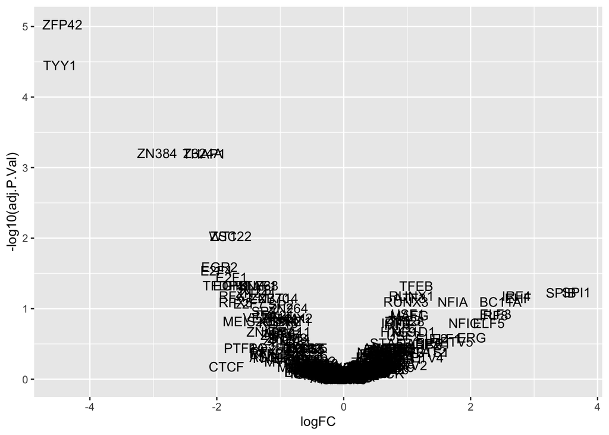

```r
res2$TF <- row.names(res2)
ggplot(res2, aes(logFC, -log10(adj.P.Val), label=TF)) + geom_text()
```

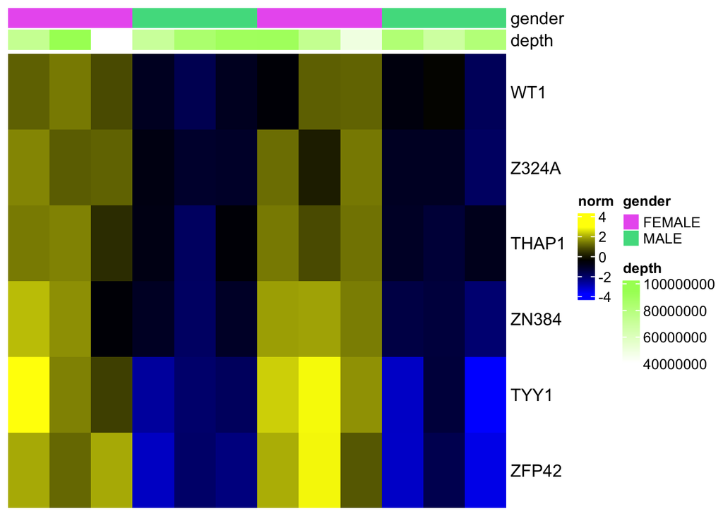

```r
sechm(dev, features = head(row.names(res2)), assayName="norm", top_annotation = c("gender", "depth"))
```